# Model recovery

Gilles Lijnzaad

2026-11-25

```r
rm(list = ls())
library(tidyverse)
library(bridgesampling)
main_dir <- "~/research/climate-RL-mod/"
recov_dir <- paste0(main_dir, "4_model_recovery/")
util_dir <- paste0(main_dir, "9_utilities/")
plot <- new.env()
source(paste0(util_dir, "plot_utils.R"), local = plot)
```

Model comparison is done using Bayes factors, as calculated by the `bridgesampling` package. I first compare fits for models `0_nolearning` and `1_std`. If BF<sub>10</sub> > 3 (moderate evidence), model 1 is the winner. If BF<sub>10</sub> < 3, model 0 is the winner, because in this situation either there is insufficient evidence for model 1 (in which case the simpler model wins), or there is evidence for model 0. We then compare fits for models `1_std` and `2_LRN_gauss`, and again, if BF<sub>21</sub> > 3, model 2 wins, and model 1 wins otherwise. I then compare the two winning models using the same criteria to find the final winner.

```r
n_runs <- 1

confusion <- data.frame(
  sim_mod = (rep(0:2, each = 3)),
  fit_mod = (rep(0:2, 3)),
  p = 0
)

fits <- list(
  "0" = NA,
  "1" = NA,
  "2" = NA
)

for (sim_model in as.character(0:2)) {
  for (run in 1:n_runs) {
    for (fit_model in as.character(0:2)) {
      fits[[fit_model]] <- readRDS(sprintf("%ssim%s/fit%s/bridge_%.03d.rds", recov_dir, sim_model, fit_model, run))
    }
    winner_I <- ifelse(bf(fits[["1"]], fits[["0"]])$bf > 3,
                       "1",
                       "0")
    winner_II <- ifelse(bf(fits[["2"]], fits[["1"]])$bf > 3,
                       "2",
                       "1")
    final_winner <- ifelse(bf(fits[[winner_II]], fits[[winner_I]])$bf > 3,
                       winner_II,
                       winner_I)
    confusion <- confusion %>%
      mutate(p = if_else(sim_mod == sim_model & fit_mod == final_winner,
                         p + 1/n_runs,
                         p))
  }
}
```

# Confusion matrix

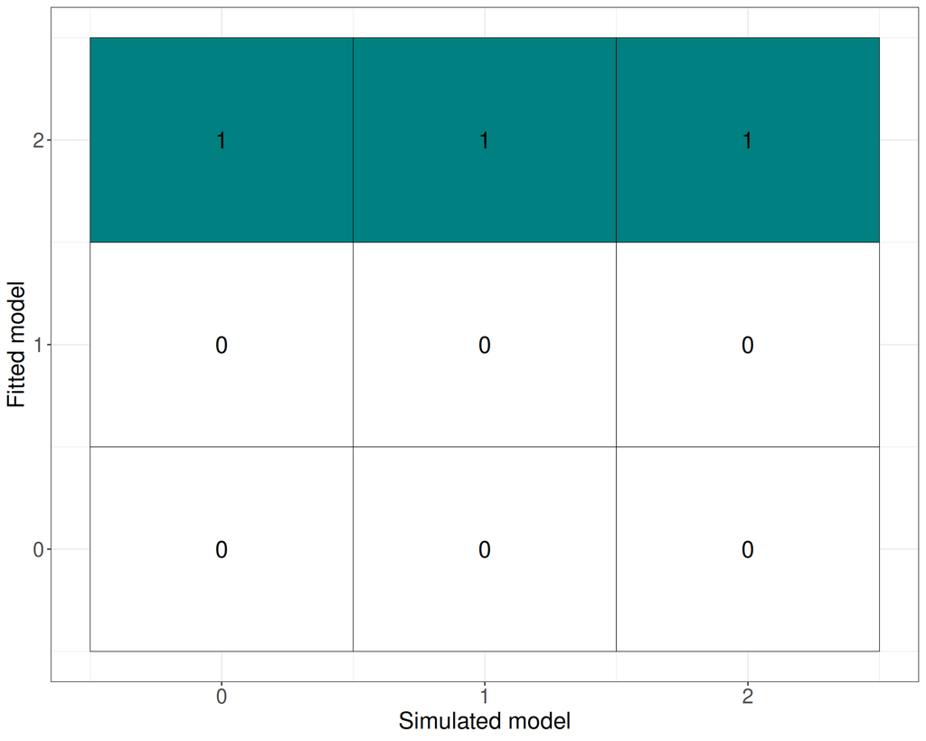

```r
ggplot(confusion, aes(x = sim_mod, y = fit_mod, fill = p)) +
  geom_tile(color = "black") +
  geom_text(aes(label = p), size = 18, size.unit = "pt") +
  scale_fill_gradient(low = "white", high = plot$my_teal, guide = "none") +
  labs(x = "Simulated model", y = "Fitted model") +
  plot$my_theme
```